# Practical Machine Learning Project

Amir Abbas Shojakhani

5/30/2020

### Background

##### Using devices such as Jawbone Up, Nike FuelBand, and Fitbit it is now possible to collect a large amount of data about personal activity relatively inexpensively. These type of devices are part of the quantified self movement – a group of enthusiasts who take measurements about themselves regularly to improve their health, to find patterns in their behavior, or because they are tech geeks. One thing that people regularly do is quantify how much of a particular activity they do, but they rarely quantify how well they do it. In this project, your goal will be to use data from accelerometers on the belt, forearm, arm, and dumbell of 6 participants. They were asked to perform barbell lifts correctly and incorrectly in 5 different ways. More information is available from the website here: http://groupware.les.inf.puc-rio.br/har (see the section on the Weight Lifting Exercise Dataset).

### Data

##### The data for this project come from this source: http://groupware.les.inf.puc-rio.br/har.

### How the model was built

##### A: Many of the variables in the dataset were summary columns and therefore had a lot of missing values. These variables were removed from our training data. We also check for Near Zero Variables and highly correlated predictors. As we were not using any time related data, all these columns were also removed along with other non-essential variables required for our prediction model.

##### B: Cross-Validation was done by separating our training data into 2 separate data sets. 80% of the training data was used to create the prediction model and the remaining 20% of the training data was used to analyze our prediction accuracy.

##### C: Prediction models based on the classification tree model and the random forest model were created and tested for accuracy. The estimated out-of-sample errors were also taken into consideration before picking out our FINAL prediction model and method.

#### Load the training and testing data sets

```r
wlexercise_training <- read.csv("https://d396qusza40orc.cloudfront.net/predmachlearn/pml-training.csv", na.strings = c("NA", "#DIV/0!", ""))
wlexercise_testing <- read.csv("https://d396qusza40orc.cloudfront.net/predmachlearn/pml-testing.csv", na.strings = c("NA", "#DIV/0!", ""))
```

##### Next I noticed that some rows feature summaries such as max, min, avg and etc. of the rows above them(A certain training window). As these columns only show the summaries of each training window on the last row of each window, most of their columns DON’T have data. As I am not relaying on the averages of the data(In this project), I will remove those variables.

```r
sum_cols <- colnames(wlexercise_training)[colSums(is.na(wlexercise_training)) > 0]
sum_cols_ind <- sapply(sum_cols, function(x) which(colnames(wlexercise_training) == x), USE.NAMES = FALSE)
training_data <- wlexercise_training[, -(sum_cols_ind)]

sum(complete.cases(training_data))
```

```
## [1] 19622
```

##### Good, we removed 100 variables and now all are rows are complete and we have no missing values.

##### Some variables in our dataset are not required for this project, such as the user_name performing the exercise and any time related data as we are not performing any time series related tests. So will go ahead and remove them also.

```r
training_data <- training_data[, -(1 : 7)]
```

##### Down to 53 variables, lets just check and see if any have a Near Zero Var, as they will NOT be helpful in our prediction model.

```r
nearZeroVar(training_data)
```

```
## integer(0)
```

##### Ok, nice to know there were NO variables with a Near Zero Var. Now let’s check if any variables have a high correlation with each other(Higher than +/- 0.9). I have written a small function to check that.

```r
show_high_cor_vars <- function(dataset) {
  for (i in 1 : (ncol(dataset) - 2)) {
    for (j in (i + 1) : (ncol(dataset) - 1)) {
      if (cor(dataset[, i], dataset[, j]) > 0.9 | cor(dataset[, i], dataset[, j]) < -0.9) {
        print(paste0(colnames(dataset[i]), " has high Cor with " ,colnames(dataset[j]), ":" ,  cor(dataset[, i], dataset[, j])))
        print("--------------------------")
      }
    }
  }
}
show_high_cor_vars(training_data)
```

```
## [1] "roll_belt has high Cor with total_accel_belt:0.980924143698649"
## [1] "--------------------------"
## [1] "roll_belt has high Cor with accel_belt_y:0.924898265903547"
## [1] "--------------------------"
## [1] "roll_belt has high Cor with accel_belt_z:-0.992008512879117"
## [1] "--------------------------"
## [1] "pitch_belt has high Cor with accel_belt_x:-0.965733396777588"
## [1] "--------------------------"
## [1] "total_accel_belt has high Cor with accel_belt_y:0.927806920706301"
## [1] "--------------------------"
## [1] "total_accel_belt has high Cor with accel_belt_z:-0.974931730075642"
## [1] "--------------------------"
## [1] "accel_belt_y has high Cor with accel_belt_z:-0.9333854057113"
## [1] "--------------------------"
## [1] "gyros_arm_x has high Cor with gyros_arm_y:-0.918182137864574"
## [1] "--------------------------"
## [1] "gyros_dumbbell_x has high Cor with gyros_dumbbell_z:-0.978950698128391"
## [1] "--------------------------"
## [1] "gyros_dumbbell_x has high Cor with gyros_forearm_z:-0.914476413154389"
## [1] "--------------------------"
## [1] "gyros_dumbbell_z has high Cor with gyros_forearm_z:0.933042179694563"
## [1] "--------------------------"
```

##### So we do have some variables that have pretty strong correlation with each other. This may make using both high correlated variables reduntent and even create some extra noise in our data and increase our Out of Sample Error. To decide which variables to keep between the 2 high correlated variables, I will use the “mutinformation” function from the “infotheo” package that will show which one of those variable, if used solely in our prediction model, will help us recognize more of the data.

```r
#Written a function to help me decide which variable has a higher mutinformation.
choose_mutinfo_var <- function(predictor1, predictor2, outcome) {
  mutinfo1 <- mutinformation(training_data[, outcome], discretize(training_data[, predictor1]))
  mutinfo2 <- mutinformation(training_data[, outcome], discretize(training_data[, predictor2]))
  ifelse(mutinfo1 >= mutinfo2, yes = paste(colnames(training_data[predictor1])), no = paste(colnames(training_data[predictor2])))
}
choose_mutinfo_var("roll_belt", "total_accel_belt", "classe") #Chose roll_belt, omitted total_accel_belt
```

```
## [1] "roll_belt"
```

```r
choose_mutinfo_var("roll_belt", "accel_belt_y", "classe") #Chose roll_belt, omitted accel_belt_y
```

```
## [1] "roll_belt"
```

```r
choose_mutinfo_var("roll_belt", "accel_belt_z", "classe") #Chose roll_belt, omitted accel_belt_z
```

```
## [1] "roll_belt"
```

```r
choose_mutinfo_var("pitch_belt", "accel_belt_x", "classe") #Chose pitch_belt, omitted accel_belt_x
```

```
## [1] "pitch_belt"
```

```r
choose_mutinfo_var("gyros_arm_x", "gyros_arm_y", "classe") #Chose gyros_arm_x, omitted gyros_arm_y
```

```
## [1] "gyros_arm_x"
```

```r
choose_mutinfo_var("gyros_dumbbell_x", "gyros_dumbbell_z", "classe") #Chose gyros_dumbbell_x, omitted gyros_dumbbell_z
```

```
## [1] "gyros_dumbbell_x"
```

```r
choose_mutinfo_var("gyros_dumbbell_x", "gyros_forearm_z", "classe") #Chose gyros_dumbbell_x, omitted gyros_forearm_z
```

```
## [1] "gyros_dumbbell_x"
```

```r
#creating a vector of the omit nominated variables to analyze later on our prediction model
omit_vars <- c("total_accel_belt", "accel_belt_y", "accel_belt_z", "accel_belt_x", "gyros_arm_y", "gyros_dumbbell_z", "gyros_forearm_z")

omit_vars_index <- sapply(omit_vars, function(x) which(colnames(training_data) == x), USE.NAMES = FALSE)
training_data_omit <- training_data[, -(omit_vars_index)] #Copy of training dataset without omittted variables
```

##### Before starting to create the prediction model, Let’s do a cross validation on our training data by separating it into 2 separate data sets to create the model on one part and test it’s prediction accuracy on the other.

##### I will create 2 separate sets of data, one including all the predictors and in the other one I will leave out the high correlated variables based on their mutual information importance we ranked before.

```r
set.seed(2468)

#All 53 predictors
intrain <- createDataPartition(y = training_data$classe, p = 0.8, list = FALSE)
Training_data_train <- training_data[intrain, ]
Training_data_test <- training_data[-intrain, ]

#Leaving out high correlated variables
intrain2 <- createDataPartition(y = training_data_omit$classe, p = 0.8, list = FALSE)
Training_data_train2 <- training_data_omit[intrain2, ]
Training_data_test2 <- training_data_omit[-intrain2, ]
```

### Creating a classification tree model

```r
rpart_1 <- rpart(classe ~ ., data = Training_data_train, method = "class")
pred_rpart_1 <- predict(object = rpart_1, newdata = Training_data_test, type = "class")
confusionMatrix(pred_rpart_1, Training_data_test$classe)
```

```
## Confusion Matrix and Statistics
##
##           Reference
## Prediction   A   B   C   D   E
##          A 999 111  14  26   9
##          B  58 501  76  69 141
##          C  34  78 555  89  78
##          D  16  57  39 431  41
##          E   9  12   0  28 452
##
## Overall Statistics
##
##                Accuracy : 0.7489
##                  95% CI : (0.735, 0.7624)
##     No Information Rate : 0.2845
##     P-Value [Acc > NIR] : < 2.2e-16
##
##                   Kappa : 0.6819
##
##  Mcnemar's Test P-Value : < 2.2e-16
##
## Statistics by Class:
##
##                      Class: A Class: B Class: C Class: D Class: E
## Sensitivity            0.8952   0.6601   0.8114   0.6703   0.6269
## Specificity            0.9430   0.8913   0.9139   0.9534   0.9847
## Pos Pred Value         0.8619   0.5929   0.6655   0.7380   0.9022
## Neg Pred Value         0.9577   0.9162   0.9582   0.9365   0.9214
## Prevalence             0.2845   0.1935   0.1744   0.1639   0.1838
## Detection Rate         0.2547   0.1277   0.1415   0.1099   0.1152
## Detection Prevalence   0.2954   0.2154   0.2126   0.1489   0.1277
## Balanced Accuracy      0.9191   0.7757   0.8626   0.8118   0.8058
```

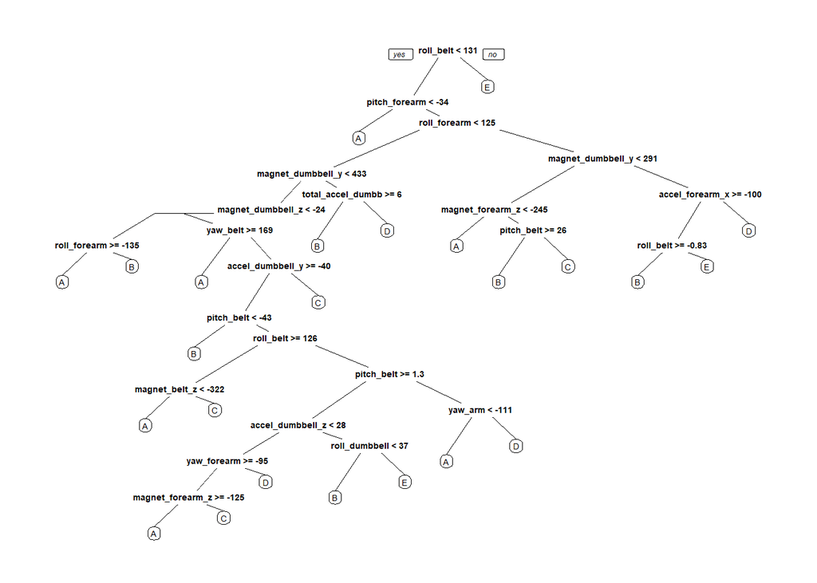

```r
prp(rpart_1)
```

```r
rpart_2 <- rpart(classe ~ ., data = Training_data_train2, method = "class")
pred_rpart_2 <- predict(object = rpart_2, newdata = Training_data_test2, type = "class")
confusionMatrix(pred_rpart_2, Training_data_test2$classe)
```

```
## Confusion Matrix and Statistics
##
##           Reference
## Prediction    A    B    C    D    E
##          A 1007  149   10   48   23
##          B   32  456   58   22   49
##          C   29   80  559  103   80
##          D   37   49   37  414   49
##          E   11   25   20   56  520
##
## Overall Statistics
##
##                Accuracy : 0.7535
##                  95% CI : (0.7397, 0.7669)
##     No Information Rate : 0.2845
##     P-Value [Acc > NIR] : < 2.2e-16
##
##                   Kappa : 0.6872
##
##  Mcnemar's Test P-Value : < 2.2e-16
##
## Statistics by Class:
##
##                      Class: A Class: B Class: C Class: D Class: E
## Sensitivity            0.9023   0.6008   0.8173   0.6439   0.7212
## Specificity            0.9181   0.9491   0.9098   0.9476   0.9650
## Pos Pred Value         0.8141   0.7391   0.6569   0.7065   0.8228
## Neg Pred Value         0.9594   0.9083   0.9593   0.9314   0.9389
## Prevalence             0.2845   0.1935   0.1744   0.1639   0.1838
## Detection Rate         0.2567   0.1162   0.1425   0.1055   0.1326
## Detection Prevalence   0.3153   0.1573   0.2169   0.1494   0.1611
## Balanced Accuracy      0.9102   0.7750   0.8636   0.7957   0.8431
```

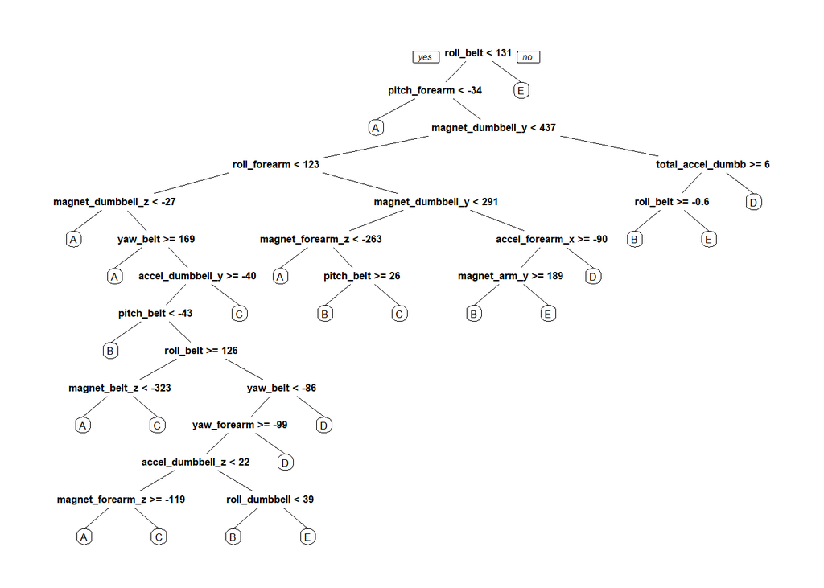

```r
prp(rpart_2)
```

##### So our classification tree model with all variables shows 74.89% accuracy with all variables and 75.35% accuracy when leaving out some high correlated variables. Leaving out the high correlated variables that had less influence on our outcome variable DID have a benefit in this model. Using this model our estimated out of sample error would be around 25%

### Creating a random forest prediction model

```r
#Using multi-core computation to speed up the prediction model
cluster_no <- makeCluster(detectCores() - 2)
registerDoParallel(cluster_no)

set.seed(1359)
rf_1 <- randomForest(classe ~ ., data = Training_data_train)

stopCluster(cluster_no)
registerDoSEQ()

pred_rf_1 <- predict(object = rf_1, newdata = Training_data_test)
confusionMatrix(pred_rf_1, Training_data_test$classe)
```

```
## Confusion Matrix and Statistics
##
##           Reference
## Prediction    A    B    C    D    E
##          A 1116    2    0    0    0
##          B    0  755    1    0    0
##          C    0    2  683    4    0
##          D    0    0    0  639    0
##          E    0    0    0    0  721
##
## Overall Statistics
##
##                Accuracy : 0.9977
##                  95% CI : (0.9956, 0.999)
##     No Information Rate : 0.2845
##     P-Value [Acc > NIR] : < 2.2e-16
##
##                   Kappa : 0.9971
##
##  Mcnemar's Test P-Value : NA
##
## Statistics by Class:
##
##                      Class: A Class: B Class: C Class: D Class: E
## Sensitivity            1.0000   0.9947   0.9985   0.9938   1.0000
## Specificity            0.9993   0.9997   0.9981   1.0000   1.0000
## Pos Pred Value         0.9982   0.9987   0.9913   1.0000   1.0000
## Neg Pred Value         1.0000   0.9987   0.9997   0.9988   1.0000
## Prevalence             0.2845   0.1935   0.1744   0.1639   0.1838
## Detection Rate         0.2845   0.1925   0.1741   0.1629   0.1838
## Detection Prevalence   0.2850   0.1927   0.1756   0.1629   0.1838
## Balanced Accuracy      0.9996   0.9972   0.9983   0.9969   1.0000
```

```r
cluster_no <- makeCluster(detectCores() - 2)
registerDoParallel(cluster_no)
set.seed(1359)
rf_2 <- randomForest(classe ~ ., data = Training_data_train2)

stopCluster(cluster_no)
registerDoSEQ()

pred_rf_2 <- predict(object = rf_2, newdata = Training_data_test2)
confusionMatrix(pred_rf_2, Training_data_test2$classe)
```

```
## Confusion Matrix and Statistics
##
##           Reference
## Prediction    A    B    C    D    E
##          A 1116    3    0    0    0
##          B    0  755    2    0    0
##          C    0    1  682    6    1
##          D    0    0    0  636    3
##          E    0    0    0    1  717
##
## Overall Statistics
##
##                Accuracy : 0.9957
##                  95% CI : (0.9931, 0.9975)
##     No Information Rate : 0.2845
##     P-Value [Acc > NIR] : < 2.2e-16
##
##                   Kappa : 0.9945
##
##  Mcnemar's Test P-Value : NA
##
## Statistics by Class:
##
##                      Class: A Class: B Class: C Class: D Class: E
## Sensitivity            1.0000   0.9947   0.9971   0.9891   0.9945
## Specificity            0.9989   0.9994   0.9975   0.9991   0.9997
## Pos Pred Value         0.9973   0.9974   0.9884   0.9953   0.9986
## Neg Pred Value         1.0000   0.9987   0.9994   0.9979   0.9988
## Prevalence             0.2845   0.1935   0.1744   0.1639   0.1838
## Detection Rate         0.2845   0.1925   0.1738   0.1621   0.1828
## Detection Prevalence   0.2852   0.1930   0.1759   0.1629   0.1830
## Balanced Accuracy      0.9995   0.9970   0.9973   0.9941   0.9971
```

### Prediction on the test dataset

```r
final_test_prediction <- predict(object = rf_1, newdata = wlexercise_testing)
final_test_prediction
```

```
##  1  2  3  4  5  6  7  8  9 10 11 12 13 14 15 16 17 18 19 20
##  B  A  B  A  A  E  D  B  A  A  B  C  B  A  E  E  A  B  B  B
## Levels: A B C D E
```